# Badanie logarytmicznych stóp zrotu

# Opis pracy:

Poniższa praca służy do analizy logarytmicznych stóp zwrotu jednej ze spółek WIG40.

## Potrzebne biblioteki:

```r
library(dplyr)
library(ggplot2)
library(psych)
library(stats)
```

# Część 1 - badanie wszystkich danych

Założenie : Ustalamy poziom istotności = 0,05

```r
dane <- read.csv("mwig40_d.csv")
```

## Obliczanie dziennych logarytmicznych stóp zwrotu

```r
dane <- dane%>%
  arrange(dane)
```

### Stworzenie RCO - stopa zamknięcia do stopy otwarcia z dnia następnego

```r
dane$RCO[1:501] <- log(dane$Otwarcie[2:501]) - log(dane$Zamkniecie[1:500])
dane$RCO[501] = NA
```

### Stworzenie ROC - stopa otwarcia do stopy zamknięcia

```r
dane$ROC <-log(dane$Zamkniecie)  - log(dane$Otwarcie)
```

### Spostrzeżenia

Warto zauważyć, że Wartości RCO są znacząco niższe, ponieważ w nocy mało się dzieje i mało osób gra na giełdzie - tym samym zmiany stóp są niskie.

## Statystyki opisowe

W celu pokazania podstawowych statystyk opisowych z pakietu “psych” i stosoujemy komendę “describe”

### ROC

```r
describe(dane$ROC)
```

```
##    vars   n mean   sd median trimmed  mad   min  max range  skew kurtosis se
## X1    1 501    0 0.01      0       0 0.01 -0.07 0.06  0.13 -0.07     3.81  0
```

- Średnia = 0, odchylenie standardowe = 0,01
- Skośność = -0,07 => rozkład bliski symetrzycznemu
- Kurtoza = 3,81 => rozkład jest leptykurtyczny

### RCO

```r
describe(dane$RCO)
```

```
##    vars   n mean sd median trimmed mad   min  max range  skew kurtosis se
## X1    1 500    0  0      0       0   0 -0.05 0.01  0.06 -6.35    87.22  0
```

- Średnia i odchylenie standardowe są w przybliżeniu równe 0, ponieważ jak wspomnieliśmy wcześniej, dane te przyjmują bardzo niskie wartości, niezauważalne przy zaokrągleniu do dwóch miejsc po przecinku.
- Skośność = -6,35 => silna skośność lewostronna
- Kurtoza = 87,22 => rozkład jest leptokurtyczny

## Wykresy

### ROC

histogram stóp zwrotu od otwarcia do zamknięcia (ROC)

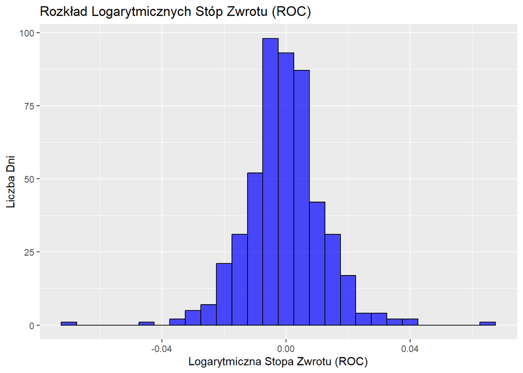

```r
ggplot(dane, aes(x = ROC)) +
  geom_histogram(binwidth = 0.005, fill = "blue", color = "black", alpha = 0.7) +
  labs(title = "Rozkład Logarytmicznych Stóp Zwrotu (ROC)",
       x = "Logarytmiczna Stopa Zwrotu (ROC)",
       y = "Liczba Dni")
```

wykres pudełkowy stóp zwrotu od otwarcia do zamknięcia (ROC)

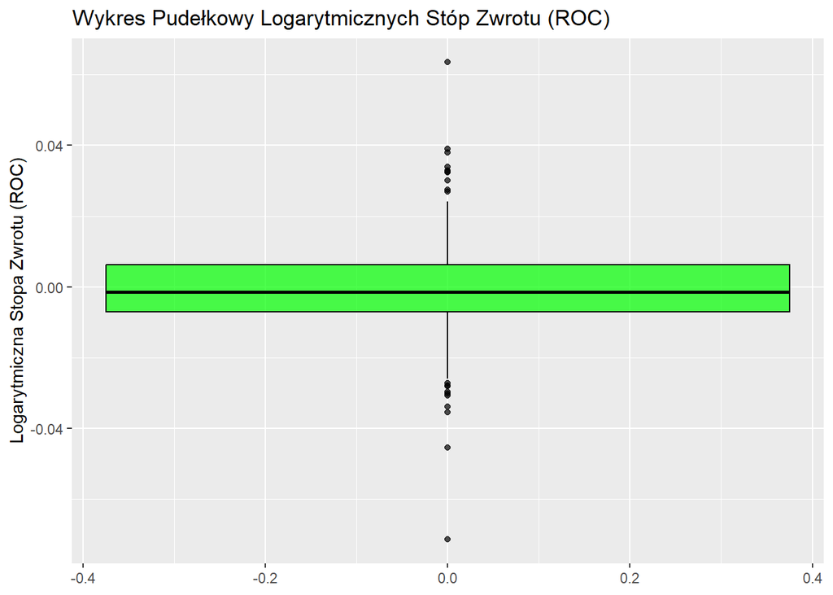

```r
ggplot(dane, aes(y = ROC)) +
  geom_boxplot(fill = "green", color = "black", alpha = 0.7) +
  labs(title = "Wykres Pudełkowy Logarytmicznych Stóp Zwrotu (ROC)",
       y = "Logarytmiczna Stopa Zwrotu (ROC)")
```

### RCO

histogram stóp zwrotu od zamknięcia do otwarcia (RCO)

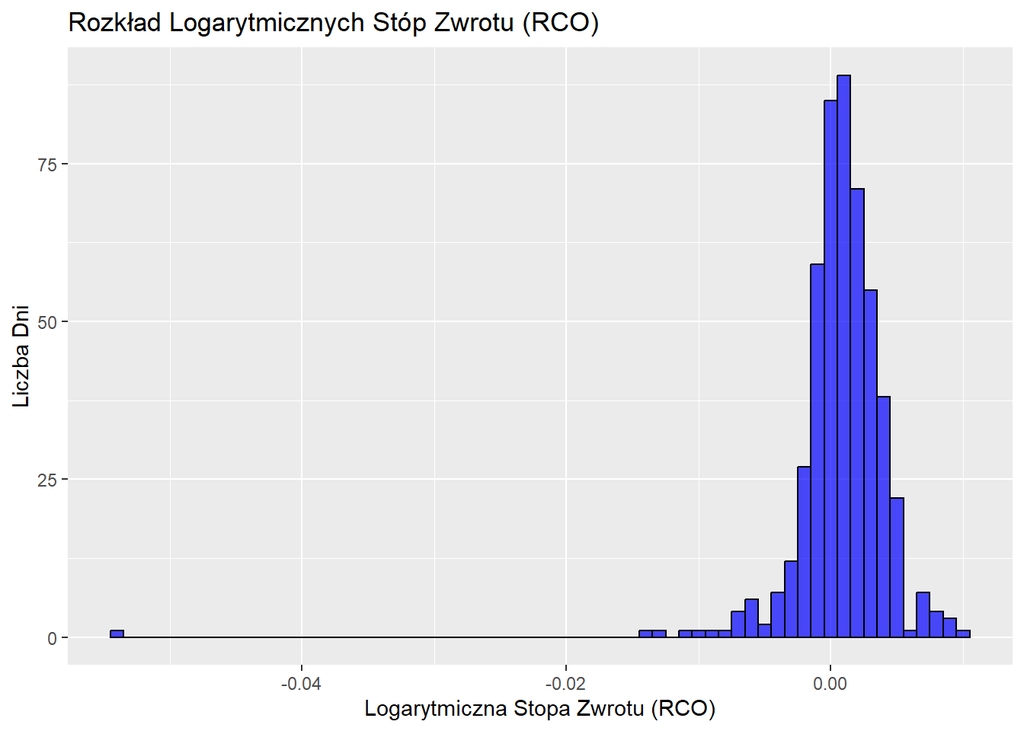

```r
ggplot(dane, aes(x = RCO)) +
  geom_histogram(binwidth = 0.001, fill = "blue", color = "black", alpha = 0.7) +
  labs(title = "Rozkład Logarytmicznych Stóp Zwrotu (RCO)",
       x = "Logarytmiczna Stopa Zwrotu (RCO)",
       y = "Liczba Dni")
```

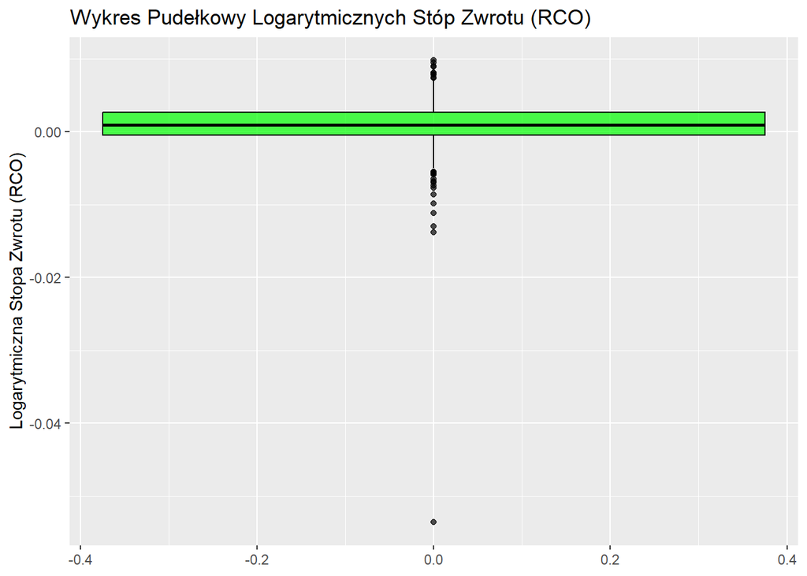

```r
ggplot(dane, aes(y = RCO)) +
  geom_boxplot(fill = "green", color = "black", alpha = 0.7) +
  labs(title = "Wykres Pudełkowy Logarytmicznych Stóp Zwrotu (RCO)",
       y = "Logarytmiczna Stopa Zwrotu (RCO)")
```

## Porównanie wartości oczekiwanych

Aby zbadać wartości oczekiwane stóp zwrotu zakładamy, że dane są niezależne i możemy użyć “t.test” z biblioteki “stats”

```r
t.test(dane$RCO, dane$ROC)
```

```
    Welch Two Sample t-test

   data:  dane$RCO and dane$ROC
   t = 2.5059, df = 593.21, p-value = 0.01248
   alternative hypothesis: true difference in means is not equal to 0
   95 percent confidence interval:
    0.0003103439 0.0025597456
   sample estimates:
       mean of x     mean of y
    0.0008037366 -0.0006313082
```

p-value jest niższy od 0,05, zatem możemy stwierdzić, że wartości oczekiwane tych rozkładów istotnie się różnią.

## Badanie normalności

```r
shapiro.test(dane$RCO)
```

```
    Shapiro-Wilk normality test

   data:  dane$RCO
   W = 0.67811, p-value < 2.2e-16
```

```r
shapiro.test(dane$ROC)
```

```
    Shapiro-Wilk normality test

   data:  dane$ROC
   W = 0.96332, p-value = 7.469e-10
```

P-value są niższe od 0,05 zatem dane nie pochodzą z rozkładu normalnego. Dlatego trzeba będzie użyć testów nieparametrycznych żeby zbadać, czy odchylenia standardowe stóp zwrotu ROC i RCO są takie same.

## Badanie odchyleń standardowych

Używamy testu “var.test” z biblioteki “stats”, który pozwoli sprawdzić, czy wariancje danych są istotnie jednakowe.

```r
var.test(dane$ROC, dane$RCO)
```

```
    F test to compare two variances

   data:  dane$ROC and dane$RCO
   F = 10.655, num df = 500, denom df = 499, p-value < 2.2e-16
   alternative hypothesis: true ratio of variances is not equal to 1
   95 percent confidence interval:
     8.939054 12.700166
   sample estimates:
   ratio of variances
             10.65501
```

Według testu istnieje statystycznie istotna różnica w wariancjach między danymi stopami, a jeśli wariancji to też i odchylenia standardowego Stwiedzamy zatem, że odchylenia standardowe stóp zwrotu są istotnie różne.

## Porównanie rozkładów

Aby zbadać czy testy mają taki sam rozkład, użyjemy testu Kolomongorowa-Smirnova:

```r
ks.test(dane$ROC, dane$RCO)
```

```
    Asymptotic two-sample Kolmogorov-Smirnov test

   data:  dane$ROC and dane$RCO
   D = 0.36514, p-value < 2.2e-16
   alternative hypothesis: two-sided
```

Jeśli przyjmiemy poziom istotności 0.05 to p value jest od niego mniejsze, więc te rozkłady tych danych są statystycznie różne

# Część 2 - Badanie próbki z danych

## Dzienne logarytmiczne stopy zwrotu

Tworzymy RCO i ROC o długości 150 - to mniej niż 1/3 początkowych danych

```r
probka = data.frame(RCO = dane$RCO[1:150], ROC = dane$ROC[1:150])
probka$RCO = dane$RCO[1:150]
probka$ROC = dane$ROC[1:150]
```

### Spostrzeżenia

Wartości RCO pozostają znacząco niższe.

## Statystyki opisowe

### ROC

```r
describe(probka$ROC)
```

```
##    vars   n mean   sd median trimmed  mad   min  max range skew kurtosis se
## X1    1 150    0 0.02      0       0 0.01 -0.07 0.06  0.13 0.13     4.17  0
```

- Średnia = 0, odchylenie standardowe = 0,02
- Skośność = 0,13 => rozkład bliski symetrzycznemu
- Kurtoza = 4,17 => rozkład jest leptykurtyczny

### RCO

```r
describe(probka$RCO)
```

```
##    vars   n mean   sd median trimmed mad   min  max range  skew kurtosis se
## X1    1 150    0 0.01      0       0   0 -0.05 0.01  0.06 -5.32    44.38  0
```

- Średnia = 0, odchylenie standardowe = 0,01
- Skośność = -5,32 => silna skośność lewostronna
- Kurtoza = 44,38 => rozkład jest leptokurtyczny

## Wykresy

### ROC

histogram stóp zwrotu od otwarcia do zamknięcia (ROC)

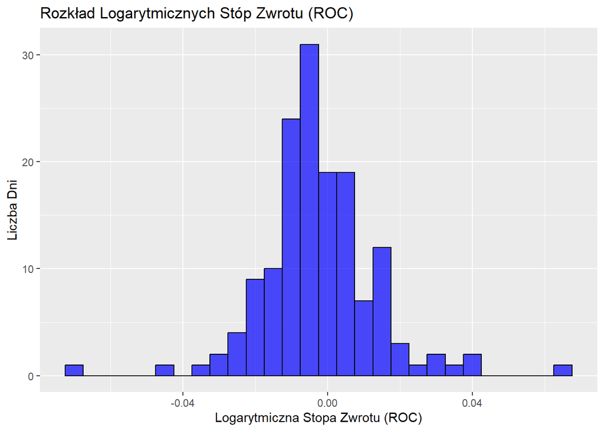

```r
ggplot(probka, aes(x = ROC)) +
  geom_histogram(binwidth = 0.005, fill = "blue", color = "black", alpha = 0.7) +
  labs(title = "Rozkład Logarytmicznych Stóp Zwrotu (ROC)",
       x = "Logarytmiczna Stopa Zwrotu (ROC)",
       y = "Liczba Dni")
```

wykres pudełkowy stóp zwrotu od otwarcia do zamknięcia (ROC)

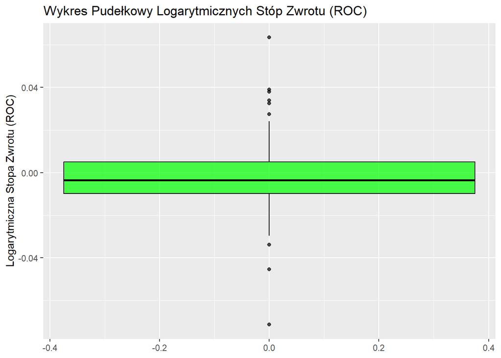

```r
ggplot(probka, aes(y = ROC)) +
  geom_boxplot(fill = "green", color = "black", alpha = 0.7) +
  labs(title = "Wykres Pudełkowy Logarytmicznych Stóp Zwrotu (ROC)",
       y = "Logarytmiczna Stopa Zwrotu (ROC)")
```

### RCO

histogram stóp zwrotu od zamknięcia do otwarcia (RCO)

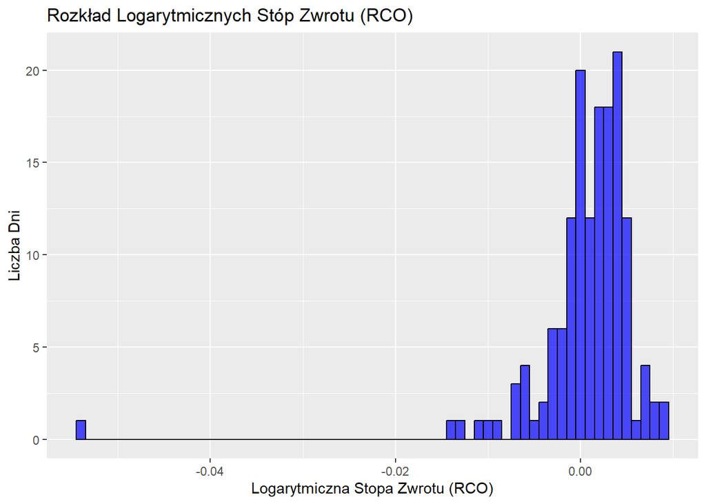

```r
ggplot(probka, aes(x = RCO)) +
  geom_histogram(binwidth = 0.001, fill = "blue", color = "black", alpha = 0.7) +
  labs(title = "Rozkład Logarytmicznych Stóp Zwrotu (RCO)",
       x = "Logarytmiczna Stopa Zwrotu (RCO)",
       y = "Liczba Dni")
```

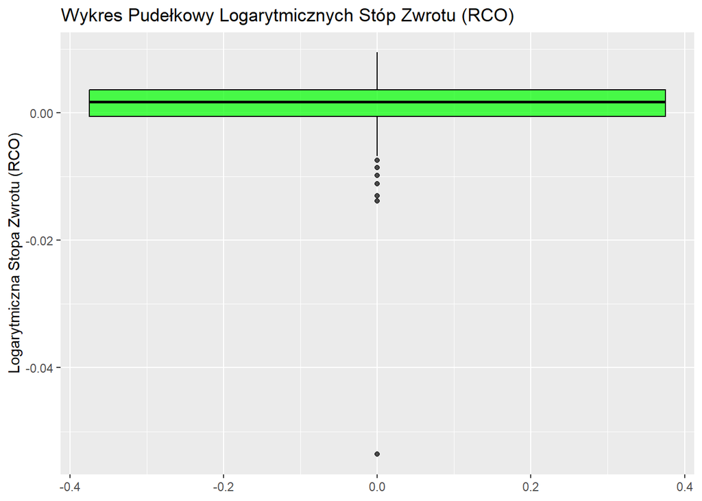

```r
ggplot(probka, aes(y = RCO)) +
  geom_boxplot(fill = "green", color = "black", alpha = 0.7) +
  labs(title = "Wykres Pudełkowy Logarytmicznych Stóp Zwrotu (RCO)",
       y = "Logarytmiczna Stopa Zwrotu (RCO)")
```

### Spostrzeżenia

Zmiana wielkości próbki zmieniła wyniki, jednak tendencje pozostają te same. Warto zauważyć, że w próbce znajduje się wartość odstająca z RCO, która występowała także w danych początkowych.

## Porównanie wartości oczekiwanych

```r
t.test(probka$RCO, probka$ROC)
```

```
    Welch Two Sample t-test

   data:  probka$RCO and probka$ROC
   t = 2.2651, df = 192.19, p-value = 0.02462
   alternative hypothesis: true difference in means is not equal to 0
   95 percent confidence interval:
    0.0003951539 0.0057206402
   sample estimates:
       mean of x     mean of y
    0.0006916641 -0.0023662329
```

p-value jest niższy od 0,05, zatem możemy stwierdzić, że wartości oczekiwane tych rozkładów istotnie się różnią.

## Badanie normalności

```r
shapiro.test(probka$RCO)
```

```
    Shapiro-Wilk normality test

   data:  probka$RCO
   W = 0.62453, p-value < 2.2e-16
```

```r
shapiro.test(probka$ROC)
```

```
    Shapiro-Wilk normality test

   data:  probka$ROC
   W = 0.9361, p-value = 2.705e-06
```

P-value są niższe od 0,05 zatem dane nie pochodzą z rozkładu normalnego. Dlatego trzeba będzie użyć testów nieparametrycznych żeby zbadać, czy odchylenia standardowe stóp zwrotu ROC i RCO są takie same.

## Badanie odchyleń standardowych

Używamy testu “var.test” z biblioteki “stats”, który pozwoli sprawdzić, czy wariancje danych są istotnie jednakowe.

```r
var.test(probka$ROC, probka$RCO)
```

```
    F test to compare two variances

   data:  probka$ROC and probka$RCO
   F = 6.7511, num df = 149, denom df = 149, p-value < 2.2e-16
   alternative hypothesis: true ratio of variances is not equal to 1
   95 percent confidence interval:
    4.890724 9.319139
   sample estimates:
   ratio of variances
             6.751099
```

Według testu istnieje statystycznie istotna różnica w wariancjach między danymi stopami, a jeśli wariancji to też i odchylenia standardowego Stwiedzamy zatem, że odchylenia standardowe stóp zwrotu są istotnie różne.

## Porównanie rozkładów

Aby zbadać czy testy mają taki sam rozkład, użyjemy testu Kolomongorowa-Smirnova:

```r
ks.test(probka$ROC, probka$RCO)
```

```
    Asymptotic two-sample Kolmogorov-Smirnov test

   data:  probka$ROC and probka$RCO
   D = 0.41333, p-value = 1.484e-11
   alternative hypothesis: two-sided
```

Jeśli przyjmiemy poziom istotności 0.05 to p value jest od niego mniejsze, więc te rozkłady tych danych są statystycznie różne

# Podsumowanie końcowe

Zarówno w statystykach wyliczonych ze wszystkich danych, jak i z próbki możemy zauważyć te same właściwości. Wartości statystyk opisowych zmieniły się, jednak na tyle mało, że ich interpretacja pozostaje taka sama. Podobnie interpretacje testów - one również pozostają takie same.